# The pipeline on the new shoes, in pictures

A visual companion to the report "Where RACs fall on new shoes": how each of the 631 new prints was calibrated, outlined, cleaned and standardized, and the pictures behind the goodness of fit. Each figure names the file it comes from.

9 November 2026 | Branch `feature/new-shoes-finish`

## 1. Putting the RACs on the image

The RAC coordinates come from a separate file, so they must be placed on each print's image with the right scale and orientation. The scale and orientation were chosen from the data: the mapping that puts the most RACs on a pixel where the sole touches the paper.

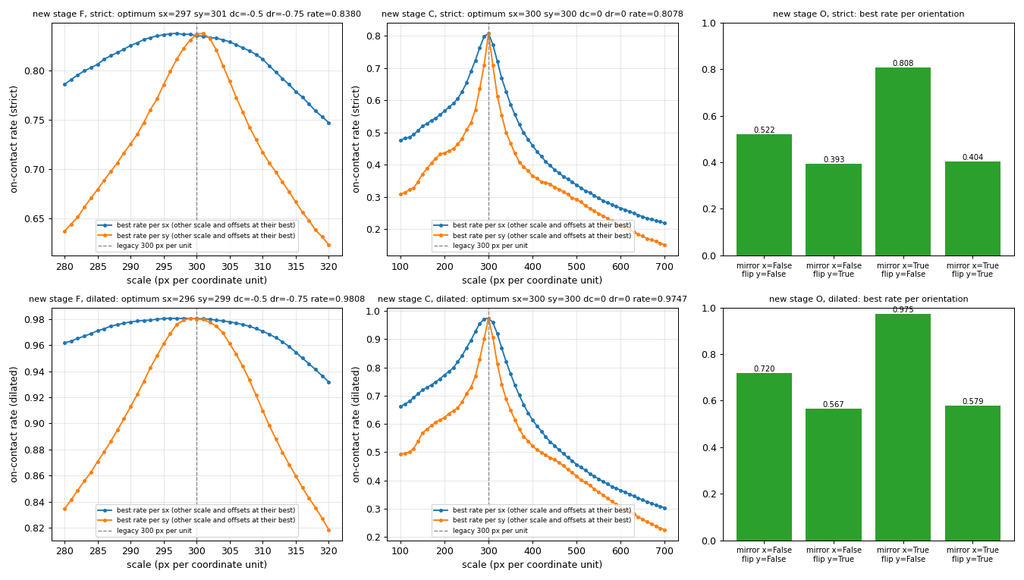

**Fig. P1. Calibrating the scale and orientation.** Share of the 20,013 new RACs that fall on a contact pixel. Top row: on the exact pixel; bottom row: within one pixel. Left and middle: as the scale varies (blue: across the shoe, orange: along it); the peak is at 300 px per coordinate unit, the scale of the original collection (dashed line). Right: the four mirror/flip orientations; only "x mirrored, y not flipped" works (81% on the pixel, 97.5% within one pixel), as for the original collection. `docs/qa/T3/new/calibration_curves_new.png`

## 2. The outline of every shoe (the snake)

An active contour, the "snake", finds the outline of each print. It starts from an ellipse, shrinks onto the print, and is then refined. The same seven shoes (nos. 1–7) are shown at each step; the full sheets for all 631 shoes are in `docs/qa/sheets_new/`.

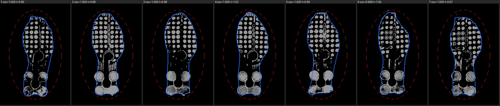

**Fig. P2a. Start.** Red dashed: the starting ellipse; blue: the first snake. The label above each shoe gives its number, the share of the contact inside the snake (cov) and the snake's tightness (t). `docs/qa/sheets_new/ellipse_first_snake/ellipse_first_snake_sheet_01_new.png`, first row

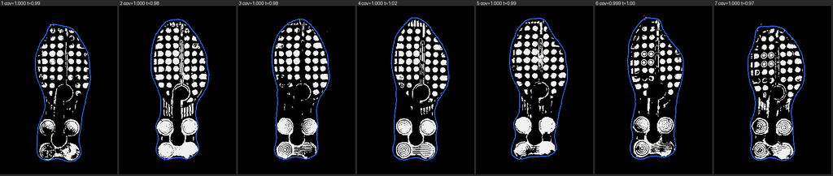

**Fig. P2b. Final snake.** Blue: the final outline; white: the contact pixels kept. `docs/qa/sheets_new/final_snake/final_snake_sheet_01_new.png`

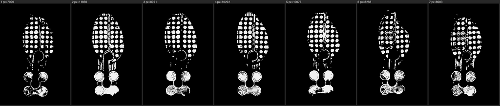

**Fig. P2c. Cleaned print.** Only the contact inside the outline is kept; px = the number of contact pixels. `docs/qa/sheets_new/cleaned/cleaned_sheet_01_new.png`

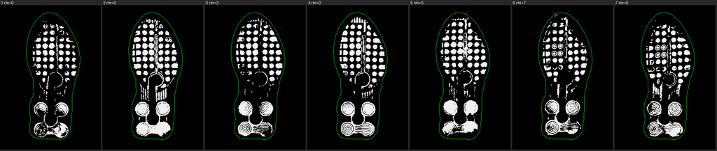

**Fig. P2d. Against the prototype.** Green: the outline of the new collection's prototype (next section). Contact outside it is removed and drawn in red; rm = the number of pixels removed (0 for most shoes). `docs/qa/sheets_new/prototype/prototype_sheet_01_new.png`